# How Does Google’s Popular Times Work?

2018-04-25

**By Sydney Yang**

You may have noticed that when you Google a café, store, or restaurant, Google presents a histogram of how popular the business is at various times of day, or days of the week. You can even see how long people typically spend there. This information, if it’s accurate, could prove invaluable to students like myself who understand all too well the frustration of making the trek to a coffee shop to study, only to be unable to find a seat. But is this technology reliable?

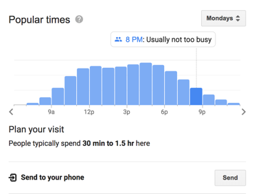

Displayed to the side of a Google search for a local café.

First, how are these histograms made? We know that Google has a (frighteningly) large amount of data on most of us. It uses GPS location signals and WiFi connections to tell where Google Maps users’ mobile phones are, and can determine from there whether or not a user is in a store. For businesses that receive more traffic, Google can calculate how many people, on average, are at each business at certain times of the day, every day of the week.

This is Google’s explanation for how it works: https://support.google.com/business/answer/6263531?hl=en

However, this information is only collected from those who allow Google to have access to their locations *all of the time*, which may not be a representative sample of all people. Maybe that mom and pop restaurant down the street only has a few customers who have their location services on, and these customers only come at the same time every morning. Or maybe many of the customers who go to the restaurant for the early-bird special don’t even have smartphones so they’re not being tracked and Google underestimates how busy it is at the restaurant.

Selection bias (who owns a smartphone and who uses location services on their phone) could be a big problem. We can shed a little light on this question. In 2015, the Pew Research Institute [reported](http://www.pewinternet.org/2015/10/29/the-demographics-of-device-ownership/) that 86% of Americans aged 18 to 29 owned smart phones, while only 30% of adults over 65 did (see chart). And they found lower-income citizens and those living in rural areas are less likely to have smart devices. The study also [found](http://www.pewresearch.org/fact-tank/2016/01/29/us-smartphone-use/) that nearly everyone who owns a smartphone uses location services (82% to 95%).

Assuming these stats haven’t changed a lot in the past few years, these differences can affect Google’s data in a few ways. It’s more likely that those who are letting Google track their every move are younger, wealthier urban dwellers. So, Google will have more accurate information on brunch rushes at a trendy restaurant than, say, early bird specials at a small-town diner. And establishments that low-income people frequent could have really inaccurate time charts.

Bottom line: if you want to find out how long you’ll have to wait for a popular restaurant in an urban area, go with what Google says. But, otherwise, you’ll want to would take Google’s suggestions with a grain of salt.

If the fact that Google tracks our locations freaks you out, don’t worry—you can disable location history for Google Maps so that Google doesn’t know where you are when you’re not using the app.

[figure not shown]